# Spatially Variable Genes

Spatial transcriptomics

SVGs

Moran's $I$

In this lesson, we will identify spatially variable genes (SVGs) whose expression changes across tissue locations. This lesson shows how to detect, visualize and prioritize SVGs as markers of spatial domains and gradients.

Author

Noor Sohail

Published

March 20, 2026

Keywords

Variable genes, Spatial patterns, Spatial autocorrelation, Spatial gradients

Approximate time: 30 minutes

## Learning objectives

In this lesson, we will:

- Define the Moran’s $I$ calculation
- Run Moran’s $I$ to identify spatially variable genes
- Visualize spatially variable genes

## Overview of lesson

At this step, instead of comparing defined cell types, you might ask which genes vary as a function of spatial location. In this lesson we will apply methods for detecting spatially variable genes (SVGs), then map and visualize their expression patterns across the tissue. These genes often serve as interpretable anchors for defining domains, building signatures and linking expression to morphology.

## Spatially variable genes (SVGs)

Spatially variable genes (SVGs) are similar in concept to highly variable genes (HVGs). HVGs were identified by evaluating the variability of gene expression across the entire dataset. However, now we have the additional layer of the spatial location for each bin. As a result, we are able to identify genes that have different levels of expression depending on which area of the tissue they are found in.

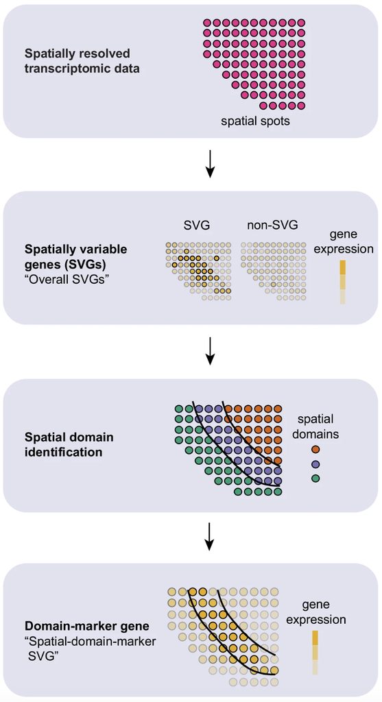

Figure 1: Schematic of how spatially variable genes present themselves in spatial data.  
*Image source: [Yan et al., 2025](https://www.nature.com/articles/s41467-025-56080-w)*

These methods can be used to identify genes that have strong spatial associations for downstream analyses - similar to how we used HVGs to calculate PCA. These SVGs can also be used to evaluate spatial niches within cell-types to assist in finding subtypes within the tissue.

Ultimately, these genes provide another peek into the spatial context of the tissue.

## Moran’s $I$

Many of the SVG algorithms are built upon the concept of [Moran’s $I$](https://en.wikipedia.org/wiki/Moran%27s_I), which is defined as “a measure of spatial autocorrelation”. The math behind the method is defined like so:

$$I =
\frac{N}{S_0}
\frac{
\sum_{i=1}^N \sum_{j=1}^N w_{ij}\,(x_i - \bar{x})(x_j - \bar{x})
}{
\sum_{i=1}^N (x_i - \bar{x})^2
}$$

where:

- $N$ is the number of spatial units, indexed by $i$ and $j$;
- $x$ is the variable of interest;
- $\bar{x}$ is the mean of $x$;
- $w_{ij}$ are the elements of the spatial-weights matrix, with $w_{ii} = 0$;
- $S_0$ is the sum of all spatial weights, $S_0 = \sum_{i=1}^N \sum_{j=1}^N w_{ij}$.

**Breakdown of Moran’s $I$ calculation**

In simpler terms, the Moran’s $I$ calculation looks at two bins at a time, $i$ and $j$. The term $w_{ij}$ is a measure of “closeness” between bins $i$ and $j$, where greater influence (weight) is given to bins that are spatially near to one another.

This calculation is done **one gene at a time**, so we get an $I$ value for each gene, represented as $x$ in the equation. Here, $\bar{x}$ is the average expression of a gene across all bins in the dataset. When we calculate $(x_i - \bar{x})$ and $(x_j - \bar{x})$, we are subtracting the normalized expression of gene $x$ for bins $i$ and $j$ from the average expression. In essence, we are calculating the deviation from the mean for both bins. This calculation is run for every pair of bins in the dataset, with the weighted products being summed together.

Additionally, we normalize the score in the denominator by calculating the gene’s variance with $\sum_{i=1}^N (x_i - \bar{x})^2$ in the dataset. The last component of the equation is to multiply $\frac{N}{S_0}$ to the results. This is to scale the final $I$ value in such a way that we can compare results from different genes against one another, even if there are different spatial weights and gene expression distributions.

**The range of values for Moran’s $I$ *E(I)* in spatial transcriptomics is usually [-1, 1].**

For a random spatial distribution, Moran’s $I$ will be near zero. A large positive value indicates the data is clustered. A large negative value indicates that the data is dispersed, meaning units that are close spatially have dissimilar variable values.

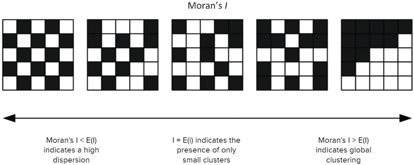

Figure 2: Range of Moran’s $I$ values, showing the range of scores that correspond to different spatial structures (dispersed, random, clustered).  
*Image source: [Tsui et al., 2022](https://www.frontiersin.org/journals/built-environment/articles/10.3389/fbuil.2022.954642/full)*

To see why this is the case, consider the expression $(x_i - \bar{x}) (x_j - \bar{x})$ in the above formula. If $x_i$ and $x_j$ are similar and far from the mean, then this product will be large and positive. If they are dissimilar (in particular, if one is well above the mean and one is far below) then this product will be large and negative. If $x_i$ and $x_j$ are both similar to the mean, then this value would be small. Note that Moran’s $I$ depends strongly on the calculation of $w_{ij}$, which represents the spatial relations of the bins. A large value $w_{ij}$ indicates that bins $i$ and $j$ are close spatially.